### exploring association rules with Apriori

```
library(arules)
library(arulesViz)
library(ggplot2)

arules：Association Rules 套件工具
arulesViz：Association Rules 可視化工具
ggplot2：繪圖及空間可視化
```

關聯規則( Association Rules )的目的是探究項目與項目之間的關係，項目可以是商店裡的物品、也可以是句中使用的單字，適用於批量購買或一系列的交易分析，也稱 MBA ( Market Basket Analysis )。關聯規則在使用上有一些前提條件，所有的資料必須是 categorical、最小化 sparsity 等，前者可透過 cut 或 discretize 方法將連續資料離散化、後者可用 pruning 方式( support-based or confidence-based )，以下使用的 Groceries 資料集來自 arules 套件中，資料前處理已經 ready，本次練習的目的是從交易資料中了解購買行為、找出規則( rules )，例如購買 A 之後可能會買什麼? 購買 A 之前已買了什麼? Groceries 資料集概述如下，包括 9835 筆交易資料、169 種品項、稀疏值( sparsity ) 2.61 %，前 5 種最常被購買的物品、有 1 筆最多購買 32 種物品紀錄…

```
## transactions as itemMatrix in sparse format with
##  9835 rows (elements/itemsets/transactions) and
##  169 columns (items) and a density of 0.02609146
##
## most frequent items:
##       whole milk other vegetables       rolls/buns             soda
##             2513             1903             1809             1715
##           yogurt          (Other)
##             1372            34055
##
## element (itemset/transaction) length distribution:
## sizes
##    1    2    3    4    5    6    7    8    9   10   11   12   13   14   15
## 2159 1643 1299 1005  855  645  545  438  350  246  182  117   78   77   55
##   16   17   18   19   20   21   22   23   24   26   27   28   29   32
##   46   29   14   14    9   11    4    6    1    1    1    1    3    1
##
##    Min. 1st Qu.  Median    Mean 3rd Qu.    Max.
##   1.000   2.000   3.000   4.409   6.000  32.000
##
## includes extended item information - examples:
##        labels  level2           level1
## 1 frankfurter sausage meat and sausage
## 2     sausage sausage meat and sausage
## 3  liver loaf sausage meat and sausage
```

- 關聯規則主要包含三個重要概念:
  1. Support: itemset 在 data 出現的頻率‧support(x) = count(x) / N
  2. Confidence: 表示 rule 強度， (x -> y) 在 x 中的比例‧confidence(x -> y) = support(x,y) / support(x)
  3. Lift: 解釋 rule 中 items 之間的關聯，通常 Lift 值大於 1 才具關聯‧lift(x -> y) = support(x,y) / support(x) * support(y)

EDA，前3筆交易資訊

```r
inspect(Groceries[1:3])
```

```
##     items
## [1] {citrus fruit,
##      semi-finished bread,
##      margarine,
##      ready soups}
## [2] {tropical fruit,
##      yogurt,
##      coffee}
## [3] {whole milk}
```

support > 0.1 的items 有 8 樣

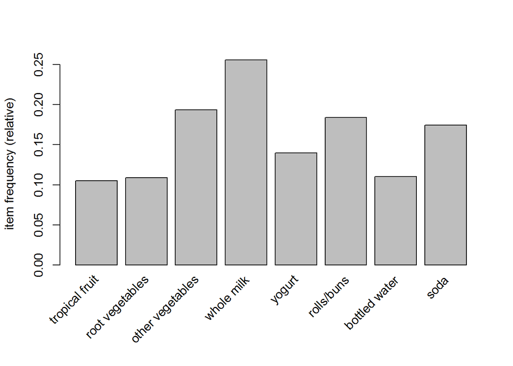

```r
#Support: itemset在data出現的頻率.support(x)=count(x)/N
itemFrequencyPlot(Groceries, support = 0.1)
```

前20項items，support 值最高為 whole milk

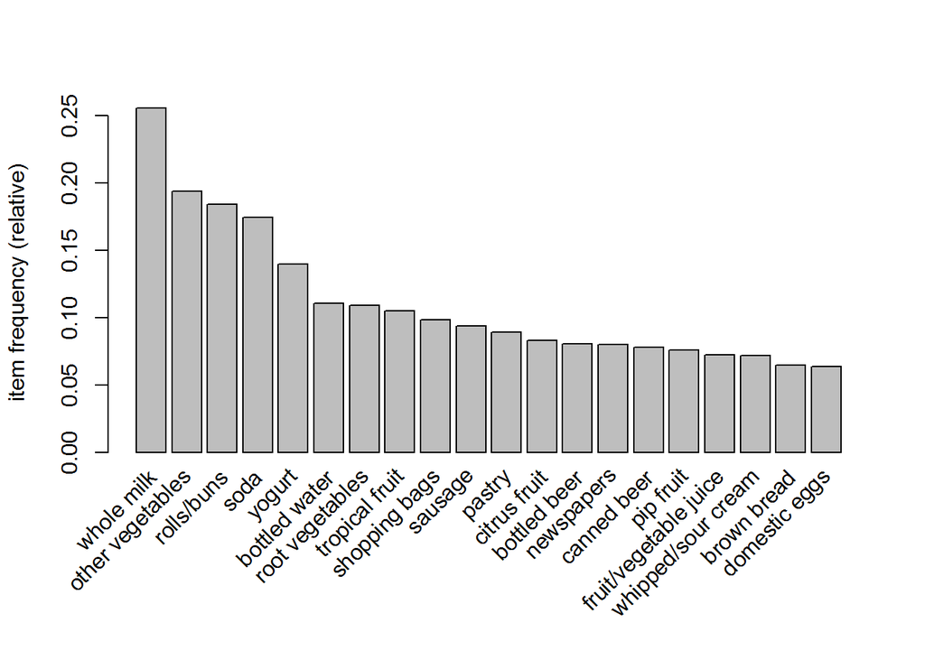

```r
itemFrequencyPlot(Groceries, topN = 20)
```

前10筆交易可視化

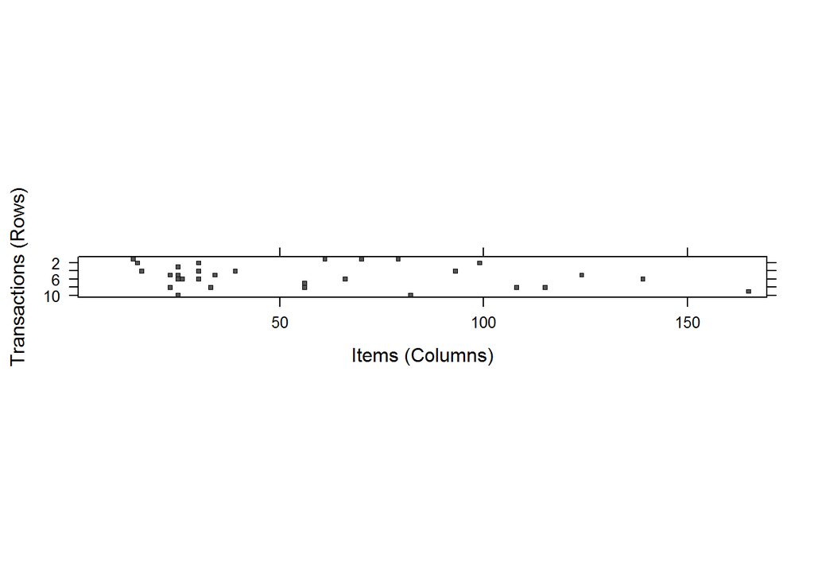

```r
#Visualizing transaction data (sparse matrix)
image(Groceries[1:10])
```

隨抽100筆交易可視化

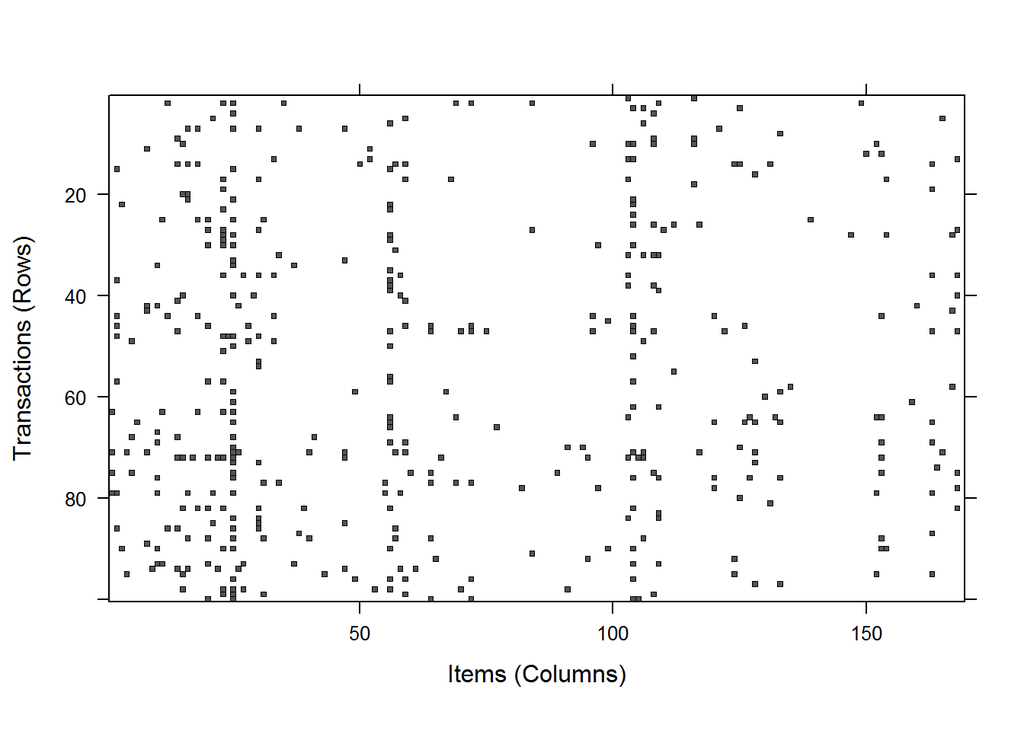

```r
#especially powerful if the items were also sorted into categories
#sample for extremely large transaction databases
image(sample(Groceries, 100))
```

rules 的決定來自 support 和 confidence 之間的權衡，為了避免產生過多、不重要的 rules，先了解 items 的 support 值，由於有 169 個 items，這裡使用的策略是參考前 1/3 (第56筆)、2/3 (第113筆)的support 值(relative)

```r
# items的相對比例(support)和絕對次數(count)
items.df <- data.frame(items = names(itemFrequency(Groceries, type = "relative")),
                       relative = itemFrequency(Groceries, type = "relative"),
                       absolute = itemFrequency(Groceries, type = "absolute"),
                       row.names = NULL)
# 排序, 第56, 113筆資料
items.df[order(items.df$relative, decreasing = T),][56,]
```

```
##          items   relative absolute
## 38 hard cheese 0.02450432      241
```

```r
items.df[order(items.df$relative, decreasing = T),][113,]
```

```
##              items    relative absolute
## 119 sparkling wine 0.005592272       55
```

接著，以上述的 support 值為起迄(0.0056 至 0.025)，confidence 值固定為 0.25，細分 10 次執行，查看產生的 rules 數(如下圖)，自訂門檻值為 < 100，因此 support 將設為 0.014222222

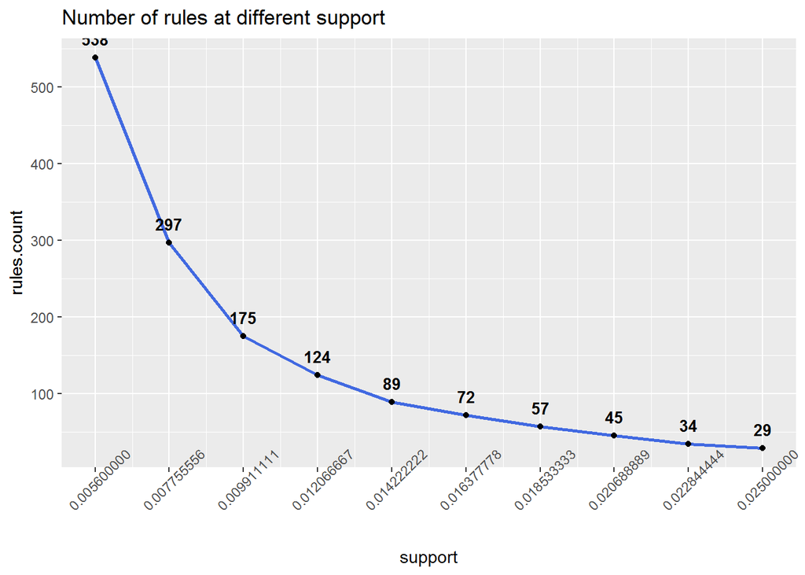

進行 apriori 演算產生 rules，取 lift > 1 者，共得到 87 條 rules，itemset = 2 種的有 66 條，itemset 為 3 的有 21 條，前 10 條 rules 如下

```r
rules <- apriori(Groceries, parameter = list(supp = 0.014222222, conf = 0.25, minlen=2))
rules <- sort(rules, decreasing = T, by = "confidence")
# filter lift < 1 的 rules
rules <- subset(rules, lift > 1)
```

```
## sizes
##  2  3
## 66 21
```

```
##      lhs                     rhs                   support confidence     lift
## [1]  {root vegetables,
##       yogurt}             => {whole milk}       0.01453991  0.5629921 2.203354
## [2]  {tropical fruit,
##       yogurt}             => {whole milk}       0.01514997  0.5173611 2.024770
## [3]  {other vegetables,
##       yogurt}             => {whole milk}       0.02226741  0.5128806 2.007235
## [4]  {other vegetables,
##       whipped/sour cream} => {whole milk}       0.01464159  0.5070423 1.984385
## [5]  {butter}             => {whole milk}       0.02755465  0.4972477 1.946053
## [6]  {curd}               => {whole milk}       0.02613116  0.4904580 1.919481
## [7]  {root vegetables,
##       other vegetables}   => {whole milk}       0.02318251  0.4892704 1.914833
## [8]  {tropical fruit,
##       other vegetables}   => {whole milk}       0.01708185  0.4759207 1.862587
## [9]  {root vegetables,
##       whole milk}         => {other vegetables} 0.02318251  0.4740125 2.449770
## [10] {domestic eggs}      => {whole milk}       0.02999492  0.4727564 1.850203
```

利用 arulesViz 套件將 rules 可視化，support 越大、圓圈越大，lift 越大、顏色越深，從下圖可發現 RHS 為根類疏菜( root vegetables )和 beef、other vegetables 等具有關聯

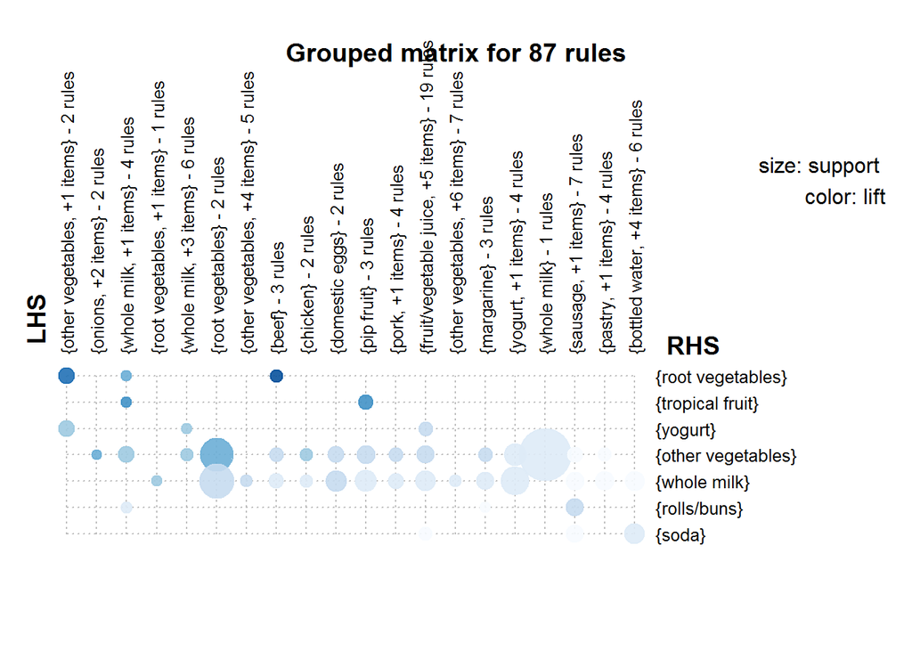

回應一開始的問題，ex: 查看買根類疏菜( root vegetables )之前會買什麼?

```r
inspect(subset(rules, rhs %in% 'root vegetables'))
```

```
##     lhs                              rhs               support
## [1] {beef}                        => {root vegetables} 0.01738688
## [2] {other vegetables,whole milk} => {root vegetables} 0.02318251
## [3] {whole milk,yogurt}           => {root vegetables} 0.01453991
##     confidence lift
## [1] 0.3313953  3.040367
## [2] 0.3097826  2.842082
## [3] 0.2595281  2.381025
```

另一種圖解可視化，可幫助了解 items 間依序關係

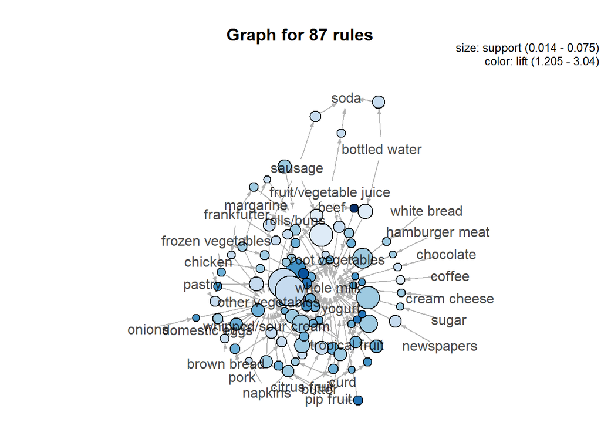

另一個問題，例如只購買優格( yogurt )的人會再買什麼?

```r
rules.yogurt <- apriori(Groceries, parameter = list(supp = 0.014222222, conf = 0.25, minlen=2),
                        appearance = list(lhs = c("yogurt"), default = "rhs"))
inspect(rules.yogurt)
```

```
##     lhs         rhs                support    confidence lift
## [1] {yogurt} => {other vegetables} 0.04341637 0.3112245  1.608457
## [2] {yogurt} => {whole milk}       0.05602440 0.4016035  1.571735
```

或者，有買優格( yogurt )的人會再買什麼?

```r
inspect(subset(rules, lhs %ain% "yogurt"))
```

```
##      lhs                          rhs                support    confidence
## [1]  {root vegetables,yogurt}  => {whole milk}       0.01453991 0.5629921
## [2]  {tropical fruit,yogurt}   => {whole milk}       0.01514997 0.5173611
## [3]  {other vegetables,yogurt} => {whole milk}       0.02226741 0.5128806
## [4]  {yogurt,rolls/buns}       => {whole milk}       0.01555669 0.4526627
## [5]  {yogurt}                  => {whole milk}       0.05602440 0.4016035
## [6]  {whole milk,yogurt}       => {other vegetables} 0.02226741 0.3974592
## [7]  {yogurt}                  => {other vegetables} 0.04341637 0.3112245
## [8]  {whole milk,yogurt}       => {rolls/buns}       0.01555669 0.2776770
## [9]  {whole milk,yogurt}       => {tropical fruit}   0.01514997 0.2704174
## [10] {whole milk,yogurt}       => {root vegetables}  0.01453991 0.2595281
##      lift
## [1]  2.203354
## [2]  2.024770
## [3]  2.007235
## [4]  1.771563
## [5]  1.571735
## [6]  2.054131
## [7]  1.608457
## [8]  1.509648
## [9]  2.577089
## [10] 2.381025
```

透過以上 association rules 產出 rules 可幫助了解 items 交叉購買之間的關係，不過有時 support 和 confidence 值高不一定是有用的 rules…此外，support 和 confidence 制訂也是主觀的，視不同資料集和目的來決定。最後產出的 rules，可以透過以下指令轉成 dataframe 或 export 檔案加以利用

```r
#轉成data.frame
df.groceryrules <- as(rules, "data.frame")
#匯成檔案
write(sort(rules, by = "lift"), file = "rules_grocery.csv", sep = ",", quote = TRUE, row.names = FALSE)
```

### Lessons Learned:

#### Association Rules with Apriori ( Market Basket Analysis )